# Assignment 2

The pirates

```r
options(warn=-1)
library(tidyverse)
library(stringr)
survey <- read_csv("survey.csv")
obs <- nrow(survey)
```

```r
#Cleaning Q32
trans32 <-survey["Q32"]
trans32 <- t(trans32)

#replace
trans32[grep("Ladl",trans32,ignore.case=TRUE)] <- "Ladle"
trans32[grep("^Spat",trans32,ignore.case=TRUE)] <- "Spatula"
trans32[grep("^Kni",trans32,ignore.case=TRUE)] <- "Knife"
trans32[grep("Spoo",trans32,ignore.case=TRUE)] <- "Spoon"
trans32[grep("fri",trans32,ignore.case=TRUE)] <- "Fridge"
trans32[grep("chop",trans32,ignore.case=TRUE)] <- "Chopsticks"
trans32[grep("none",trans32,ignore.case=TRUE)] <- NaN
trans32[grep("some",trans32,ignore.case=TRUE)] <- NaN
trans32[grep("thing",trans32,ignore.case=TRUE)] <- NaN

trans32 <- t(trans32)
trans32 <- tolower(trans32)
survey["Q32"] <- trans32
```

```r
#Cleaning Q25
trans25 <-survey["Q25"]
trans25 <- t(trans25)

#replace
trans25[grep("swim",trans25,ignore.case=TRUE)] <- "Swimming"
trans25[grep("Football",trans25,ignore.case=TRUE)] <- "Soccer"
trans25[grep("yes",trans25,ignore.case=TRUE)] <- NaN
trans25[grep("choosing",trans25,ignore.case=TRUE)] <- NaN
trans25[grep("electronic",trans25,ignore.case=TRUE)] <- NaN

trans25 <- t(trans25)
trans25 <- tolower(trans25)
survey["Q25"] <- trans25
```

```r
#cleaning Q24
trans24 <-survey["Q24"]

trans24 <- as.numeric(as.character(trans24$Q24)) #converts too numeric

survey["Q24"] <- trans24
```

```r
#Cleaning Q23
trans23 <-survey["Q23"]
##trans23 <- t(trans23)

trans23 <- as.numeric(as.character(trans23$Q23))

#below loop looks for an age entered as a D.O.B and calcs age
for(i in 1:obs){
  if(!is.na(as.numeric(as.character(trans23[i])))){
    if((trans23[i] > 1000)){
      trans23[i] <- 2018 - trans23[i]
    }
  }
}

survey["Q23"] <- trans23
```

```r
#Cleaning Q22
trans22 <-survey["Q22"]
for(i in 1:obs){
  if(is.na(as.numeric(trans22[i,1]))){
    trans22[i,1] <- as.numeric(gsub("([^0-9]+)", "", trans22[i,1])) #extracts numbers from string
  }
}
trans22 <- as.numeric(as.character(trans22$Q22))
survey["Q22"] <- trans22
```

```r
#Cleaning Q21
#removed non sensical answers like 7;30, typo? or misread question? too hard to know so just removed
trans21 <-survey["Q21"]
trans21 <- as.numeric(as.character(trans21$Q21))
survey["Q21"] <- trans21
```

```r
#cleaning 2
trans2 <- survey["Q2"]

for(i in 1:obs){
  if(is.na(as.numeric(as.character(trans2[i,1])))){
    if(grepl("/", as.character(trans2[i,1]))){ #calcs decimal from fraction
      num = as.numeric(substr(as.character(trans2[i,1]),1,1))
      den = as.numeric(substr(as.character(trans2[i,1]),3,3))
      trans2[i,1] = num/den
    }
    if(grepl("h", as.character(trans2[i,1]))||grepl("H", as.character(trans2[i,1])) ){
      trans2[i,1] <- as.numeric(gsub("([0-9]+).*$", "\\1", trans2[i,1])) #extracts numbers from string
    }
  }
}

#remove values greater than 24
for(i in 1:obs){
  if(!is.na(trans2[i,1])){
    if(as.numeric(trans2[i,1]) > 24){ trans2[i,1] <- NA}
  }
}

survey["Q2"] <- trans2
```

```r
#cleaning 4
trans4 <- survey["Q4"]
for(i in 1:obs){
  trans4[i,1] <- tolower(trans4[i,1]) #converts to lowercase
  if(grepl("hip", as.character(trans4[i,1]))){ #accounts for differnt ways of saying hip hop
    trans4[i,1] <- "hip hop"
  }
  #removes music string from responses
  if(grepl("music", as.character(trans4[i,1]))){
    x <- unlist(strsplit(as.character(trans4[i,1]), " "))
    x <- x[!x %in% "music"]
    if(!is_empty(x)){trans4[i,1] <- as.character(x)}
    else{ trans4[i,1] = NA}
  }
}
survey["Q4"] <- trans4
```

```r
#cleaning 5
trans5 <- survey["Q5"]
for(i in 1:obs){
  #for answers with 'hours'
  if(grepl("h", as.character(trans5[i,1]))||grepl("H", as.character(trans5[i,1])) ){
      trans5[i,1] <- as.numeric(gsub("([0-9]+).*$", "\\1", trans5[i,1])) #extracts numbers from string
  }
  if((!is.na(as.numeric(trans5[i,1])))&&(as.numeric(trans5[i,1])>168)){trans5[i,1] <- NA} #remove non-sensical answers, answer over 168
}
survey["Q5"] <- trans5
```

```r
#cleaning 9
trans9 <- survey["Q9"]
for(i in 1:obs){
  trans9[i,1] <- tolower(trans9[i,1]) #converts to lowercase
  #removes people who dont watch tv
  if((grepl("n/a", as.character(trans9[i,1])))||grepl("dont", as.character(trans9[i,1]))||grepl("don't", as.character(trans9[i,1]))||grepl("none", as.character(trans9[i,1]))||grepl("nothing", as.character(trans9[i,1]))||grepl("do not", as.character(trans9[i,1]))||grepl("no", as.character(trans9[i,1]))){
    trans9[i,1] <- NA
  }
}
survey["Q9"] <- trans9
```

```r
#cleaning 10
trans10 <- survey["Q10"]
for(i in 1:obs){
  if(is.na(as.numeric(trans10[i,1]))){trans10[i,1] <- NA} #convets strings to na
}

survey["Q10"] <- trans10
```

```r
#cleaning 13
trans13 <- survey["Q13"]
for( i in 1:obs){
  if(grepl("$", as.character(trans13[i,1]))||grepl("dollars", as.character(trans13[i,1])) ){
      trans13[i,1] <- as.numeric(gsub("([^0-9]+)", "", trans13[i,1])) #extracts numbers from string
  }
}
survey["Q13"] <- trans13
```

```r
#cleaning 1
trans1 <- survey["Q1"]
for( i in 1:obs){
  if(!is.na(trans1[i,1])){
    if(trans1[i,1]=="A"){trans1[i,1] <- 1}
    if(trans1[i,1]=="B"){trans1[i,1] <- 2}
    if(trans1[i,1]=="C"){trans1[i,1] <- 3}
    if(trans1[i,1]=="D"){trans1[i,1] <- 4}
    if(trans1[i,1]=="E"){trans1[i,1] <- "other"}
  }
}
survey["Q1"] <- trans1
```

```r
#cleaning 26 - Load survey data into a column vector. Iterate through each element replacing A, B and C with Female, Male and NA respectively. Finally overwrite the relevant column in the survey data with the updated column vector.
trans26 <- survey["Q26"]
for( i in 1:obs){
  if(!is.na(trans26[i,1])){
    if(trans26[i,1]=="A"){trans26[i,1] <- "Female"}
    if(trans26[i,1]=="B"){trans26[i,1] <- "Male"}
    if(trans26[i,1]=="C"){trans26[i,1] <- NA}
  }
}
survey["Q26"] <- trans26
```

```r
#cleaning 8 - Load survey data into a column vector. Iterate through each element replacing A, B, C, D and E with 0-3, 3-6, 6-9, 9-12 and 12+ respectively. Finally overwrite the relevant column in the survey data with the updated column vector.
trans8 <- survey["Q8"]
for( i in 1:obs){
  if(!is.na(trans8[i,1])){
    if(trans8[i,1]=="A"){trans8[i,1] <- "0-3"}
    if(trans8[i,1]=="B"){trans8[i,1] <- "3-6"}
    if(trans8[i,1]=="C"){trans8[i,1] <- "6-9"}
    if(trans8[i,1]=="D"){trans8[i,1] <- "9-12"}
    if(trans8[i,1]=="E"){trans8[i,1] <- "12+"}
  }
}
survey["Q8"] <- trans8
```

```r
trans5 <- survey["Q5"]
trans5 <- as.numeric(as.character(trans5$Q5))
survey["Q5"] <- trans5
```

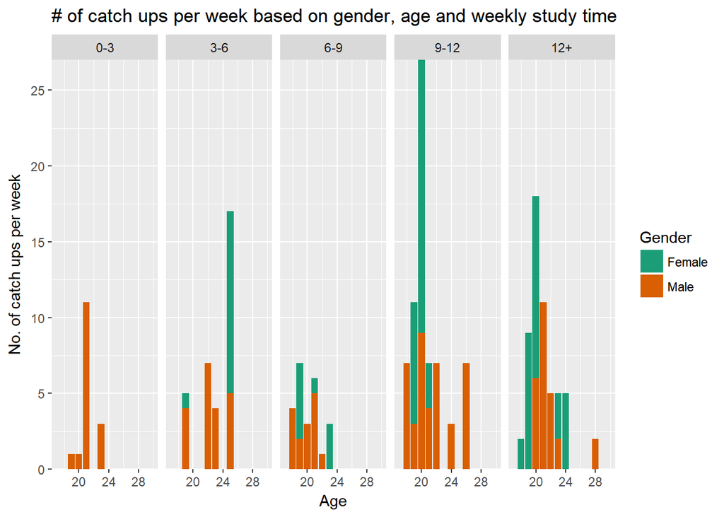

```r
#Plot 1
#Create data frame with all relevant survey data so it can be manipulated without consequence.
df <- data.frame(
  age = survey["Q23"],
  hangout = survey["Q22"],
  gender = survey["Q26"],
  studyTime = survey["Q8"]
)
#Rename columns so they are comprehendable.
colnames(df) <- c("Age", "No. of catch ups per week", "Gender", "studyTime")
#Initialize vector. Iterate through all elements of dataframe and append to vector a boolean such that any row with an NA is excluded from the data

df$studyTime_f = factor(df$studyTime, levels=c('0-3','3-6','6-9','9-12','12+'))
#plot
ggplot(na.omit(df), aes(x = Age, y = `No. of catch ups per week`, fill = Gender)) +
  geom_bar(stat = "identity") +
  facet_grid(~ studyTime_f) +
  ggtitle("# of catch ups per week based on gender, age and weekly study time") +
  scale_y_continuous(expand = c(0,0)) + #Fixes y-axis starting below 0
  scale_fill_brewer(palette="Dark2") +
  scale_x_continuous(limits=c(17, 30))
```

Plot 1 : No. of catch ups per week based on gender, age and time spent studying per week

From the graph, we can see that there are only males that spend on average 0-3 hours of studying a week. We can also observe an upwards trend for females when it comes to number of hours studied per week, with predominantly females in the 12+ hours spent on studying a week facet. The people who tend to study about 6-9 hours a week generally spend fewer hours to catch up with friends too, this may indicate that these student tend to enjoy a more balanced along with more personal down time. The ages are predominantly around the 18-24 year olds, which is reasonable as we are all university student. However there is one student who is about 28 years of age, this could indicate that there might be a masters student in our class.

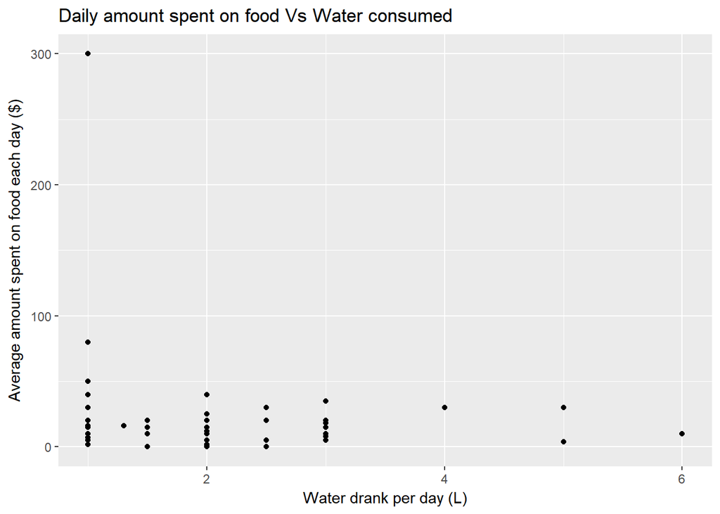

```r
#Plot 2
#Create data frame with all relevant survey data so it can be manipulated without consequence.
df <- data.frame(
  water = survey["Q10"],
  food = survey["Q13"]
)
#Rename columns so they are comprehendable.
colnames(df) <- c("Water drank per day (L)", "Average amount spent on food each day ($)")
df$`Average amount spent on food each day ($)` <- mapply(df$`Average amount spent on food each day ($)`, FUN=as.numeric)
df$`Water drank per day (L)` <- mapply(df$`Water drank per day (L)`, FUN=as.numeric)

ggplot(data=na.omit(df), aes(x=`Water drank per day (L)`, y=`Average amount spent on food each day ($)`)) + ggtitle("Daily amount spent on food Vs Water consumed") +
  geom_point() #+ geom_smooth()
```

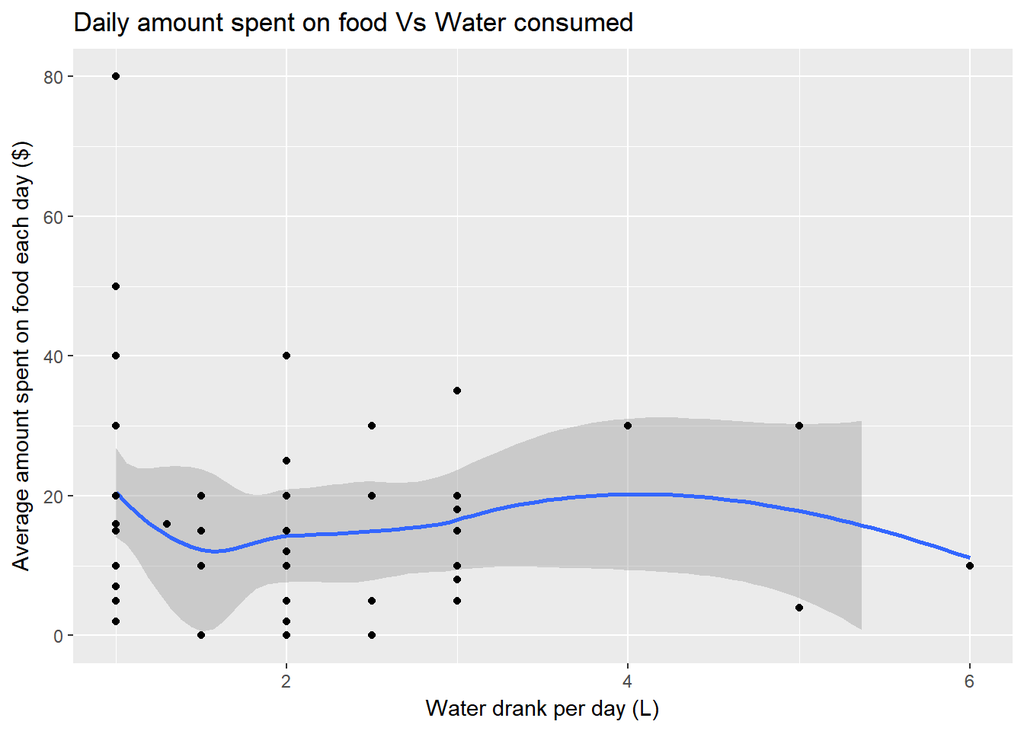

```r
#plot excluding outlier
ggplot(data=na.omit(df), aes(x=`Water drank per day (L)`, y=`Average amount spent on food each day ($)`)) + ggtitle("Daily amount spent on food Vs Water consumed") + geom_smooth() +
geom_point() + scale_y_continuous(limits = c(0, 80))
```

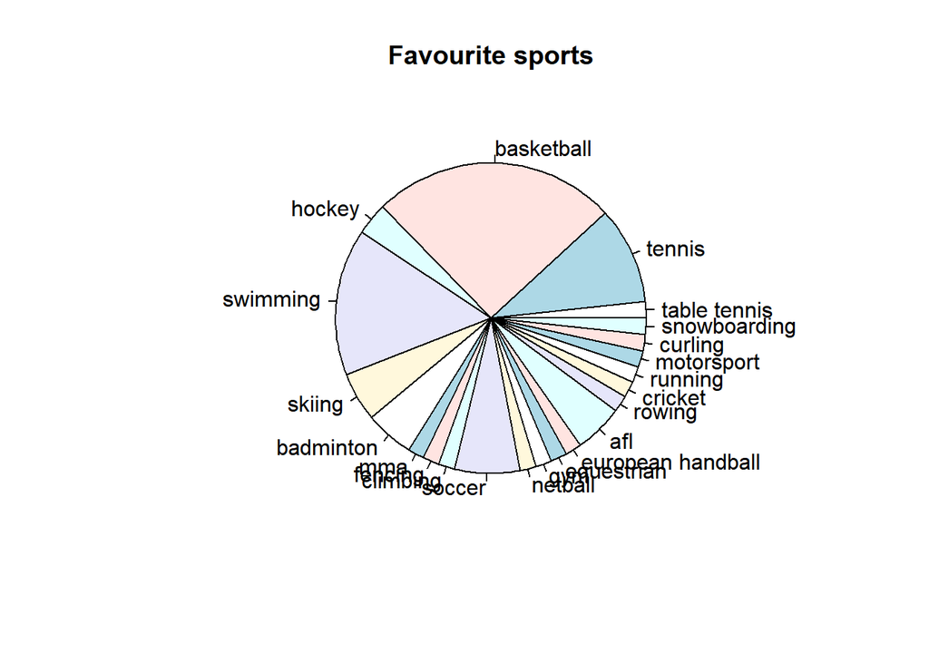

```r
#Plot 3
#Declare names array to track sports and freq array to count how many times a sport is chosen.
names = c("0")
freq = c(0)

#Initialize vector. Iterate through all elements of dataframe and append to vector a boolean such that any row with an NA is excluded from the data
rows_to_keep = c()
for (i in 1:obs) {
  if(!(is.na(survey["Q25"][i, 1]))){
    if(survey["Q25"][i, 1]=="nan" || survey["Q25"][i, 1]=="sleep") {
      rows_to_keep[i] = FALSE
    } else {
      rows_to_keep[i] = TRUE
    }
  } else {
    rows_to_keep[i] = FALSE
  }
}
data <- survey["Q25"][rows_to_keep,]

#Variable used to continue through a nested loop
success = FALSE
#Iterate through all elements of data
for (i in 1:obs) {
  if(!(is.na(data[i, 1]))) {
    #Check if sport has already been added to names array
    for (j in 1:length(names)) {
      if (data[i, 1]==names[j]) {
        #if so, then increase the count for that sport and continue to the next element.
        freq[j] = freq[j]+1
        success = TRUE
        break
      }
    }
    if (success) {
      success = FALSE
    } else {
      #if not, a new elements needs to be added to names array for the sport and a count of 1 added for it in the freq array.
      if (names[j]=="0") {
        names[j] = data[i, 1]
        freq[j] = 1
      } else {
        names[j+1] = data[i, 1]
        freq[j+1] = 1
      }
    }
  }
}
#Create data frame with all relevant survey data so it can be manipulated without consequence.
df <- data.frame(
  unlist(names),
  unlist(freq)
)
#Rename columns so they are comprehendable.
colnames(df) <- c("Favourite sport", "Count")

pie(freq, labels=names, main="Favourite sports")
```

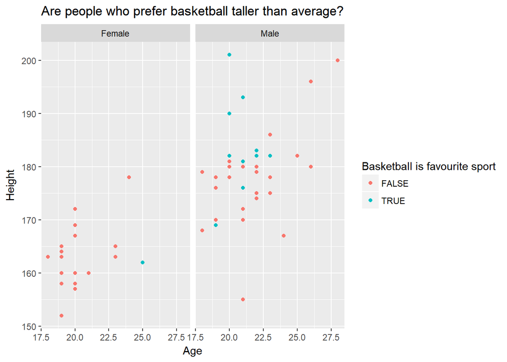

```r
#Plot of age vs height faceted by gender, also shows if fav sport is bball or not

df <- data.frame(
  age = survey["Q23"],
  height = survey["Q24"],
  favourite_sport = survey["Q25"],
  gender = survey["Q26"]
)

for( i in 1:nrow(df)){
  if(grepl("basketball", as.character(df[i,3])))
    df[i,3] = TRUE
  else df[i,3] = FALSE
}

ggplot(na.omit(df), aes(x=Q23, y=Q24, colour = Q25)) + ggtitle("Are people who prefer basketball taller than average?") +
  geom_point() + facet_wrap(~Q26) + labs(x = 'Age', y = 'Height', colour = 'Basketball is favourite sport')
```

From the scatterplot above, we plotted height against age, while faceting gender, along with colour coding to see if basketball was a student’s favourite sport. It can be observed that there is some correlation between height and if basketball is a student’s favourite sport for male student, as the students who chose basketball as their favourite sport are situated in the upper half of the graph except for a couple of exceptions. Majority of females did not have basketball as a favourite sport, and it may be due to females resorting more towards netball, which has a similar style to basketball.

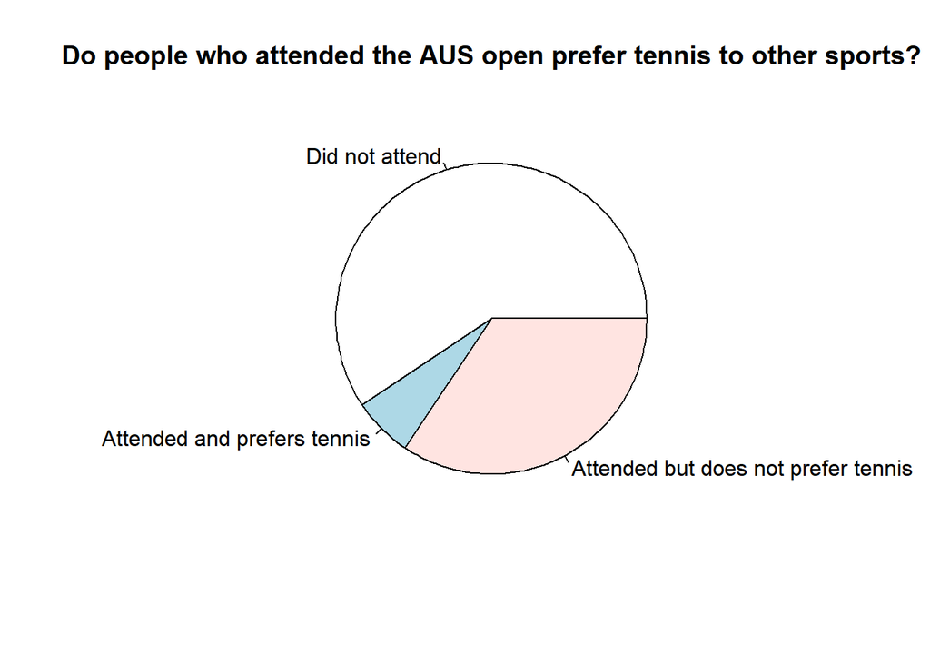

```r
df <- data.frame(
  favourite_sport = survey["Q25"],
  aus_open = survey["Q29"]
)

aus_open_and_tennis <- 0
open_count <- 0
for (i in 1:obs) {
  if(grepl("A", as.character(df[i,2]))){
    open_count = open_count + 1
    if(grepl("tennis", as.character(df[i,1]))&&!grepl("table", as.character(df[i,1]))){
      aus_open_and_tennis = aus_open_and_tennis + 1
    }
  }
}

pie_parts <- c(nrow(df)-open_count, aus_open_and_tennis, open_count-aus_open_and_tennis)
lbs <- c("Did not attend", "Attended and prefers tennis", "Attended but does not prefer tennis")
pie(pie_parts, labels = lbs, main = 'Do people who attended the AUS open prefer tennis to other sports?')
```

It can be seen from the pie chart that majority of the students in this class did not attend the AUS open, and this shows the lack of interest in the sport in our class. The chart also shows that many students went to the Australian Open but did not prefer tennis to other sports, this may be due to casual tennis fans who attends the Australian open more for the experience and the fun of it rather than their love for the sport. This may also suggest that the annual Australian Open is an event so popular that it manages to attract all casual sports fans.

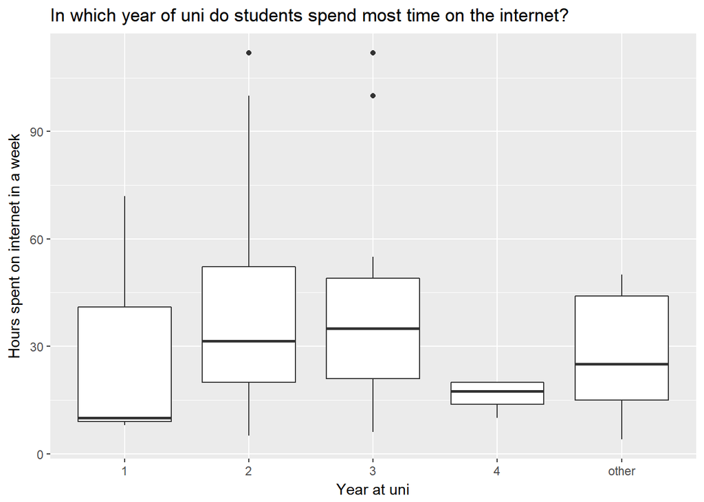

```r
library(forcats)

df <- data.frame(
  yearOfStudy = survey["Q1"],
  internet = survey["Q5"]
)

colnames(df) <- c("Year at uni", "Hours spent on internet in a week")

ggplot(data=na.omit(df), aes(x=`Year at uni`, y=`Hours spent on internet in a week`)) +
  geom_boxplot() +
  ggtitle("In which year of uni do students spend most time on the internet?")
```

From the graph, we can say 2nd and 3rd year students spend the most time on the internet. This may be attributed to more online study and recreation required to survive 2nd and 3rd year. As this is a commerce unit, most degree lengths will be 3 years. Students falling into the 4th year and other category are most likely double degree or part time students. Interestingly there is a large variation in the hours spent online for 1st years which may suggest most 1st years may not be as studious or spend most of their free time getting involved in university social activities.